# Homework 06

Huanhuan Yue netID hyue4

Due: Friday, October 27, 11:59 PM

Please see the [homework instructions document](https://daviddalpiaz.github.io/stat430fa17/homework_policy.html) for detailed instructions and some grading notes. Failure to follow instructions will result in point reductions.

For this homework we will use data found in `wisc-trn.csv` and `wisc-tst.csv` which contain train and test data respectively. `wisc.csv` is provided but not used. This is a modification of the Breast Cancer Wisconsin (Diagnostic) dataset from the UCI Machine Learning Repository. Only the first 10 feature variables have been provided. (And these are all you should use.)

- UCI Page
- [Data Detail](https://archive.ics.uci.edu/ml/machine-learning-databases/breast-cancer-wisconsin/wdbc.names)

You should consider coercing the response to be a factor variable.

You should use the `caret` package and training pipeline to complete this homework. Any time you use the `train()` function, first run `set.seed(1337)`.

# Exercise 1 (Tuning KNN with `caret`)

**[6 points]** Train a KNN model using all available predictors, **no data preprocessing**, 5-fold cross-validation, and a well chosen value of the tuning parameter. Consider $k = 1, 3, 5, 7, \ldots, 101$. Store the tuned model fit to the training data for later use. Plot the cross-validated accuracies as a function of the tuning parameter.

```r
library(readr)
library(caret)
```

```r
library(lattice)
library(ggplot2)
library(class)
```

```r
#read in dataset
train1=read.csv("wisc-trn.csv")
test1=read.csv("wisc-tst.csv")
#convert to factor
train1$class=factor(train1$class)
test1$class=factor(test1$class)
set.seed(1337)
```

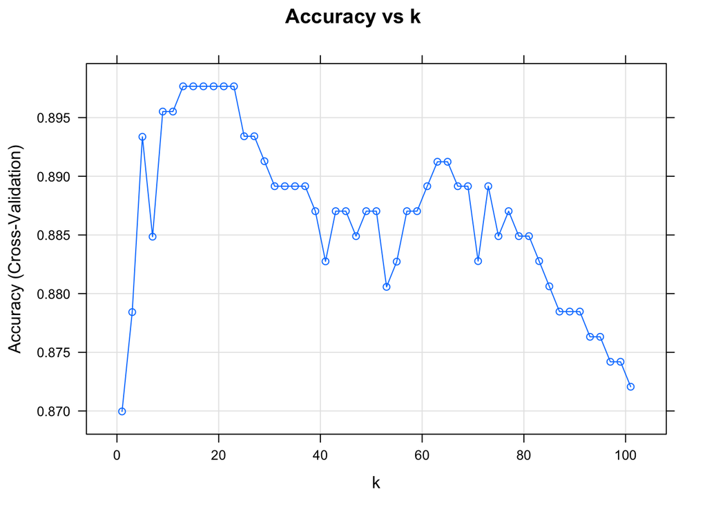

```r
knn1=train(
  class ~.,
  data=train1,
  method="knn",
  trControl = trainControl(method = "cv", number = 5),
  tuneGrid=expand.grid(k=seq(1,101,by=2))
)

plot(knn1,xlab="k",main="Accuracy vs k")
```

***

# Exercise 2 (More Tuning KNN with `caret`)

**[6 points]** Train a KNN model using all available predictors, predictors scaled to have mean 0 and variance 1, 5-fold cross-validation, and a well chosen value of the tuning parameter. Consider $k = 1, 3, 5, 7, \ldots, 101$. Store the tuned model fit to the training data for later use. Plot the cross-validated accuracies as a function of the tuning parameter.

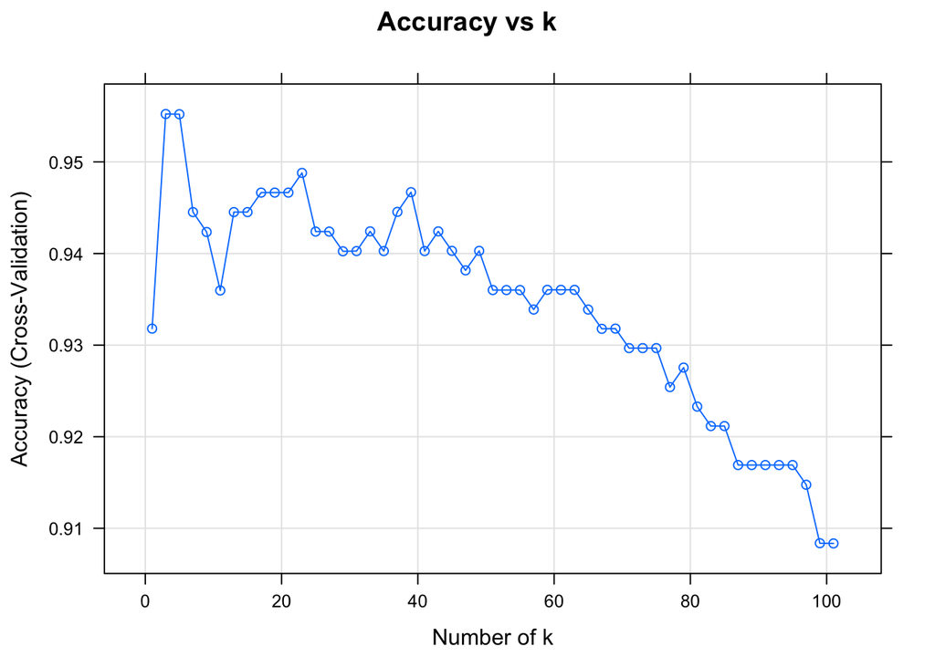

```r
set.seed(1337)
knn2=train(
  class ~.,
  data=train1,
  method="knn",
  trControl = trainControl(method = "cv", number = 5),
  preProcess=c("center","scale"),
  tuneGrid=expand.grid(k=seq(1,101,by=2))
)
plot(knn2,xlab="Number of k",main="Accuracy vs k")
```

# Exercise 3 (Random Forest?)

**[6 points]** Now that we’ve introduced `caret`, it becomes extremely easy to try different statistical learning methods. Train a random forest using all available predictors, **no data preprocessing**, 5-fold cross-validation, and well a chosen value of the tuning parameter. Using `caret` to perform the tuning, there is only a single tuning parameter, `mtry`. Consider `mtry` values between 1 and 10. Store the tuned model fit to the training data for later use. Report the cross-validated accuracies as a function of the tuning parameter using a well formatted table.

```r
set.seed(1337)
rfmod=train(
  class~.,
  data=train1,
  method="rf",
  trControl=trainControl(method="cv",number=5),
  tuneGrid=expand.grid(mtry=seq(1,10))
)
knitr::kable(rfmod$results[,1:2],caption="Cross-validated Accuracies",align='c')
```

Cross-validated Accuracies

| mtry | Accuracy |
| --- | --- |
| 1 | 0.9402654 |
| 2 | 0.9466484 |
| 3 | 0.9402654 |
| 4 | 0.9487989 |
| 5 | 0.9403111 |
| 6 | 0.9403111 |
| 7 | 0.9381835 |
| 8 | 0.9424388 |
| 9 | 0.9403111 |
| 10 | 0.9381835 |